## (Without Paired DNA) Integrated Pipeline for Identifying Tumor Subclones

Jiazhen Rong, Chi-Yun Wu, Zhang Lab, University of Pennsylvania

2024-08-27

### Introduction

This tutorial aims to provide an integrated pipeline example for when paired DNA data is not available.

In this tutorial, we will use a spatial transcriptomics colorecral carcinoma dataset generated by our study (10x Genomics chemistry, will be available upon publication).

### Load Data

```r
library(Clonalscope)
library(Seurat)
library(AUCell)
library(Matrix)
library(dplyr)
library(Seurat)
library(patchwork)

# load example data from standard 10x genomics format}
mtx <- readMM("data/V11Y04-378-A1/filtered_feature_bc_matrix/matrix.mtx.gz")
barcodes <- read.table("data/V11Y04-378-A1/filtered_feature_bc_matrix/barcodes.tsv.gz", stringsAsFactors = F, sep='\t', header=F)
features <- read.table("data/V11Y04-378-A1/filtered_feature_bc_matrix/features.tsv.gz", stringsAsFactors = F, sep='\t', header=F)
colnames(mtx) <- barcodes[,1]
rownames(mtx) <- features[,1]
# load spatial spot_datainates
spot_data = as.data.frame(read.table("data/V11Y04-378-A1/spatial/tissue_positions_list.csv",sep=","))
colnames(spot_data) <-c("barcode","include","row","col","image_row","image_col")
rownames(spot_data) <- spot_data[,1]
gene_symbols = features[,2] # Gene Symbol

# set file path for results results
dir_path = "your_output_path";dir.create(dir_path,recursive = T)
```

### Initial Estimation of Normal Reference

In the recent update, we have add function **FindNormalReference()** for automatically get an initial estimation of normal cells, which will be utilized as control/reference cells for CNV estimation.

However, to get the most refined and accurate annotation, users with professional knowledge on the disease and tumor related biomarkers could view this specific [tutorial](https://github.com/seasoncloud/Clonalscope/tree/identify_normal_cells_noWGS/samples/V11Y04-378-A1) for annotating tumor/normal cells when paired DNA is not available.

- **Option 1: Based on the marker genes**

  We utilizes Seurat to clustering the cells/spots into transcriptionally different clusters and check for enrichment of common single cell gene signatures from [MSigDB SCSig collection](https://www.gsea-msigdb.org/gsea/msigdb/supplementary_genesets.jsp) [1]. For this CRC example, we set *tissue_type* to be **Large_Intestine** and input several keywords of known normal celltypes. The keywords of known normal cell type shall be separated with “|”.

  For the full list of available tissue types, please type *?FindNormalReference()*.

  ```r
  # Identify
  normal_celltype=c("immune|endothelial|stromal|fibroblast|Goblet_Progenitor|Secretory_Progenitor")
  initial_normal_spots = FindNormalReference(counts=mtx, gene_symbols=gene_symbols,method="marker",marker_source="MSigDB",tissue_type="Large_Intestine",normal_celltype = normal_celltype)
  ```

- **Option 2: Based on the First Principal Component**

  To utilize PCA based separation instead of marker genes, the following commands could be run:

  ```r
  initial_normal_spots = FindNormalReference(counts=mtx, gene_symbols=gene_symbols,method="pca")
  ```

Then prepare the initial normal reference into Clonalscope input format:

```r
# setting normal/reference cells in the annotation file
celltype = barcodes; rownames(celltype) = barcodes[,1]
celltype$annotation = "tumor"
celltype[initial_normal_spots,"annotation"] = "normal"
```

### Clustering on All Cells/Spots

Now we can run the subclone detection on all cell/spot barcodes.

Here we show the pipeline with the initial estimated normal cells as reference and with chromosomal arm level segments for initial estimation.

```r
# Size of each chromosome (hg19 and GRCh38 are provided.)
size=read.table("../Clonalscope/data-raw/sizes.cellranger-GRCh38-1.0.0.txt", stringsAsFactors = F)
# List of cyclegenes retrieved from the "CopyKAT"package (https://github.com/navinlabcode/copykat)
cyclegenes=readRDS("../Clonalscope/data-raw/cyclegenes.rds")
# bed file indicating gene positions (hg19 and GRCh38 are provided.)
bed=read.table("../Clonalscope/data-raw/hg38.genes.bed", sep='\t', header = T)

# Generate segmentation table for each chromosome arm (w/o paired WGS)
chrarm=read.table("../Clonalscope/data-raw/cytoarm_table_hg38.txt", stringsAsFactors = F, sep='\t', header=T)
chrarm=chrarm[order(as.numeric(chrarm[,1]),as.numeric(chrarm[,3])),]
bin_bed=chrarm[,-2]

seg_table_filtered=data.frame("chr"=bin_bed[,1], 'start'=as.numeric(bin_bed[,2]),
                              'end'=as.numeric(bin_bed[,3]), 'states'=1, 'length'=as.numeric(bin_bed[,3])-as.numeric(bin_bed[,2]),
                              'mean'=0, 'var'=0, 'Var1'=1:nrow(bin_bed),'Freq'=50000,
                              'chrr'=paste0(bin_bed[,1],":", bin_bed[,2]), stringsAsFactors = F)

# Filtering HLA and cell cycle genes
Input_filtered <- FilterFeatures(mtx=mtx, barcodes=barcodes, features=features, cyclegenes=cyclegenes)

# Remove raw inputs
rm(mtx); rm(barcodes); rm(features)

# normally run Clonalscope algorithm
Cov_obj <- RunCovCluster(mtx=Input_filtered$mtx, barcodes=Input_filtered$barcodes,
                         features=Input_filtered$features, bed=bed,alpha=5,beta=5,
                         celltype0=celltype, var_pt=0.99, var_pt_ctrl=0.99, include='all',
                         alpha_source='all', ctrl_region=NULL,
                         seg_table_filtered=seg_table_filtered, size=size,
                         dir_path=dir_path, breaks=50, prep_mode = 'intersect', est_cap = 2,
                         clust_mode='all')
saveRDS(Cov_obj,paste0(dir_path,"Cov_obj_chrarm.rds"))
```

### Final Tumor/Normal Assignment based on CNV Loads

Finally, the tumor and normal status could be assigned based on CNV loads based on **MalignantAssignment()** function.

```r
Cov_obj <- readRDS(paste0(dir_path,"Cov_obj_chrarm.rds"))
final_tn_res <- MalignantAssignment(Cov_obj,cutoff=0.5)
```

We can visualize the clustering result that’s only on tumor spots in space:

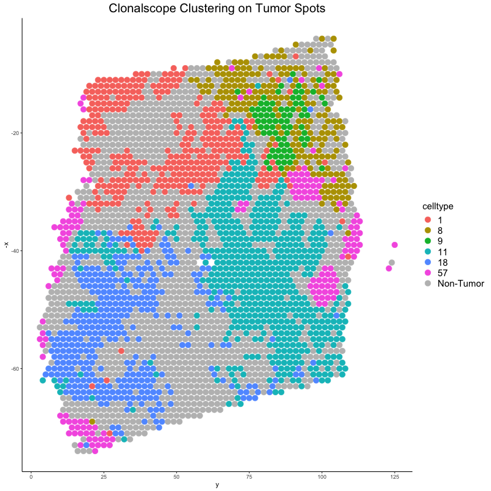

```r
clusters_clonalscope = cbind(barcode=names(Cov_obj$result_final$result$Zest), # barcode
                             clusters=Cov_obj$result_final$result$Zest)        # clusters

clusters_clonalscope = clusters_clonalscope[names(final_tn_res$final_assignment)[final_tn_res$final_assignment == "Tumor"],] # only keep tumor spots based on final assignment

SpatialPlot(spot_data,clusters_clonalscope,save=T,dir_path,title="Clonalscope Clustering on Tumor Spots",cluster=T,pt_size=4)
```

### Reference

1. Subramanian A, Tamayo P, Mootha VK, Mukherjee S, Ebert BL, Gillette MA, Paulovich A, Pomeroy SL, Golub TR, Lander ES, Mesirov JP. Gene set enrichment analysis: a knowledge-based approach for interpreting genome-wide expression profiles. Proc Natl Acad Sci U S A. 2005 Oct 25;102(43):15545-50. doi: 10.1073/pnas.0506580102. Epub 2005 Sep 30. PMID: 16199517; PMCID: PMC1239896.
2. STARCH: Elyanow R, Zeira R, Land M, Raphael BJ. STARCH: copy number and clone inference from spatial transcriptomics data. Phys Biol. 2021 Mar 9;18(3):035001. doi: 10.1088/1478-3975/abbe99. PMID: 33022659; PMCID: PMC9876615.